# Exploratory Data Analysis Of laptops dataset

#### RAM & Price Relationship:

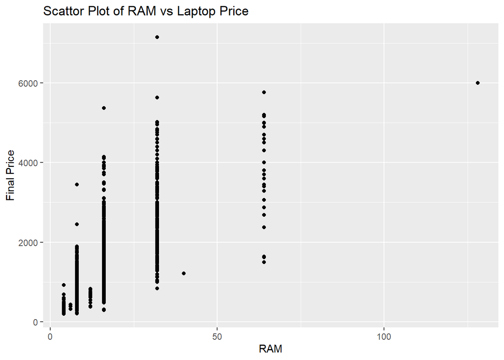

```r
#RAM & Price relationship via scatter plot
ggplot(laptops, aes(x = RAM, y = Final.Price))+
  geom_point()+
  labs(title = 'Scattor Plot of RAM vs Laptop Price',
       x = "RAM", y = 'Final Price')
```

- The scatter plot reveals the relationship between laptop RAM (in GB) and prices.
- For laptops with 4GB RAM, a cluster is observed in the $200-$800 price range.Laptops with 8GB RAM cluster between $200 and $2000, with fewer above $2000. The 16GB RAM category is dense, spanning $200-$4000, with fewer observations beyond $3000.

-64GB RAM laptops are sparsely represented. An isolated 120GB RAM laptop is priced around $6000, suggesting uniqueness.

#### Storage Type Distribution:

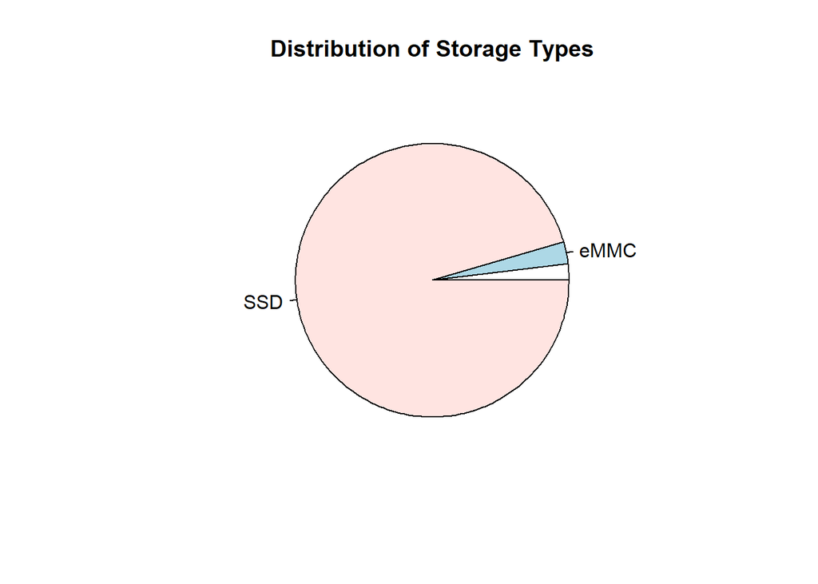

```r
#distribution of storage types using pie chart
storage_distribution <- table(laptops$Storage.type)
pie(storage_distribution, labels = names(storage_distribution),
    main = "Distribution of Storage Types")
```

- The pie chart illustrates the predominance of SSD storage types among laptops.
- SSD storage types represent the majority of laptops in the dataset, while eMMC storage types constitute a very small proportion.